# Project 6 : Material manufacturing

## Lasso and Ridge regression

### Lasso Regression

1. Lasso Regression is a method of dimensionality reduction. In lasso Regression, the co-efficients of the linear model are brought down to zero when the features are not considered important.
2. The regularization parameter **alpha** is initially set to 1. This is the case when the model is **underfitted** and most of the co-efficients are brought down to 0.
3. With the relaxation of the alpha parameter, the co-efficients start to gain a non-zero value.
4. The more the alpha is relaxed, the lasso regression tends to resemble a linear regression.

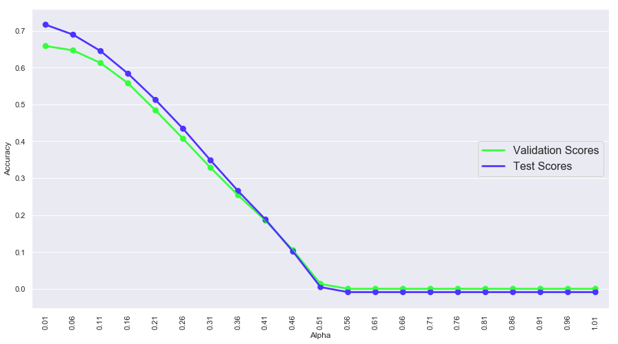

```python
lasso_val_scores=[]
lasso_test_scores=[]
alpha = np.arange(0.01,1.05,0.05)

# np.arange() function creates an array of c values which have recurring decimal numbers.
# So to trim them upto 2 decimal places, we use the float positional function to re-format the c values.
for i in range(0,len(alpha)):
    alpha[i] = np.format_float_positional(alpha[i],precision=4)

# Creating the lasso regressor with different alpha values.
for a in alpha:
    lasso = Lasso(alpha=a,random_state=10)
    lasso.fit(X_train_2,y_train_2)
    lasso_val_scores.append(lasso.score(X_val_2,y_val_2))
    lasso_test_scores.append(lasso.score(X_test_2,y_test_2))


plt.figure(figsize=(15,8))
sns.pointplot(x = alpha,y=lasso_val_scores,color="#33FF3C",label="Validation Scores"),
sns.pointplot(x = alpha,y=lasso_test_scores,color="#4C33FF",label="Test Scores")
leg = plt.legend(labels=['Validation Scores','Test Scores'], loc ='center right',prop={'size':16})
leg.legendHandles[0].set_color("#33FF3C")
leg.legendHandles[1].set_color("#4C33FF")
plt.xlabel("Alpha")
plt.ylabel("Accuracy")
plt.xticks(rotation=90)
plt.show()

# The lasso regression with least relaxed parameter of alpha = 0.01 provides the same accuracy as a linear regression.
# However, with the increase in the alpha value, the co-efficients get stricter and pulls the accuracy down to ZERO.
```

### Ridge Regression

1. The Ridge regressor is however a little different from the lasso regressor.
2. For low value of the regularization parameter alpha, the model is relaxed and the co-efficients in ridge regression resemble closely the co-efficients of linear regression.
3. With the increase in alpha, the co-efficients start to shrink but they do not drop down to zero unline lasso regression.

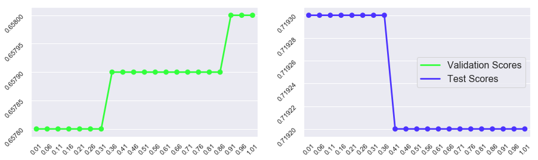

```python
ridge_val_scores=[]
ridge_test_scores=[]
alpha = np.arange(0.01,1.05,0.05)

# np.arange() function creates an array of c values which have recurring decimal numbers.
# So to trim them upto 2 decimal places, we use the float positional function to re-format the c values.
for i in range(0,len(alpha)):
    alpha[i] = np.format_float_positional(alpha[i],precision=4)

# Creating the Ridge regressor with different alpha values.
for a in alpha:
    ridge = Ridge(alpha=a,random_state=10)
    ridge.fit(X_train_2,y_train_2)
    ridge_val_scores.append(float(np.format_float_positional(ridge.score(X_val_2,y_val_2),precision=4)))
    ridge_test_scores.append(float(np.format_float_positional(ridge.score(X_test_2,y_test_2),precision=4)))


fig,axes = plt.subplots(nrows=1,ncols=2,figsize=(15,4))
ax1 = sns.pointplot(x=alpha,y=ridge_val_scores,color="#33FF3C",ax=axes[0])
ax2 = sns.pointplot(x = alpha,y=ridge_test_scores,color="#4C33FF",label="Test Scores",ax=axes[1])
leg = plt.legend(labels=['Validation Scores','Test Scores'], loc ='center right',prop={'size':16})
leg.legendHandles[0].set_color("#33FF3C")
leg.legendHandles[1].set_color("#4C33FF")
#plt.xlabel("Alpha")
#plt.ylabel("Accuracy")
ax1.tick_params(labelrotation=45)
ax2.tick_params(labelrotation=45)
#plt.show()

# The ridge regression with least relaxed parameter of alpha = 0.01 provides the same accuracy as a linear regression both in validation and test sets.
# However, with the increase in the alpha value, the co-efficients get stricter and pulls the accuracy but it does not come down to zero like lasso regression.
# The decrease in accuracy in this case is very less.
```

## ----------------------------------------------Random Forest--------------------------------------------------

```python
from sklearn.ensemble import RandomForestRegressor
```

```python
RF_regressor_original = RandomForestRegressor(n_estimators=50,max_depth=13,random_state=10)
RF_regressor_original.fit(X_train_2,y_train_2)
```

```
RandomForestRegressor(bootstrap=True, criterion='mse', max_depth=13,
           max_features='auto', max_leaf_nodes=None,
           min_impurity_decrease=0.0, min_impurity_split=None,
           min_samples_leaf=1, min_samples_split=2,
           min_weight_fraction_leaf=0.0, n_estimators=50, n_jobs=None,
           oob_score=False, random_state=10, verbose=0, warm_start=False)
```

```python
RF_val_original = RF_regressor_original.score(X_val_2,y_val_2)
RF_val_original
```

```
0.9017206573566576
```

```python
RF_test_original = RF_regressor_original.score(X_test_2,y_test_2)
RF_test_original
```

```
0.9010026253356067
```

## Tuning hyper parameters

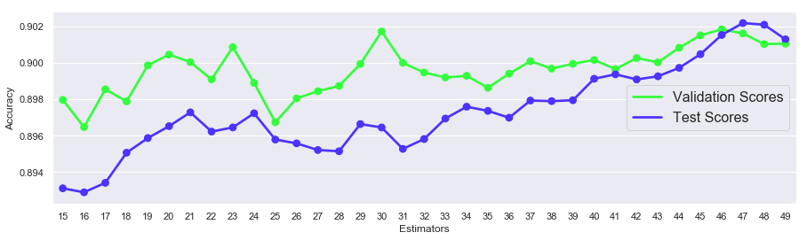

```python
RF_val_scores = []
RF_test_scores = []
estimators = np.arange(15,50)
for n in estimators:
    RF_regressor = RandomForestRegressor(n_estimators=n,max_depth=13,random_state=10) # Since we found 13 as the regularized depth.
    RF_regressor.fit(X_train_2,y_train_2)
    RF_val_scores.append(RF_regressor.score(X_val_2,y_val_2))
    RF_test_scores.append(RF_regressor.score(X_test_2,y_test_2))


RF_score = max(RF_test_scores)
#Plotting comparison graph for different number of estimators
plt.figure(figsize=(15,4))
sns.pointplot(x = estimators,y=RF_val_scores,color="#33FF3C",label="Validation Scores"),
sns.pointplot(x = estimators,y=RF_test_scores,color="#4C33FF",label="Test Scores")
leg = plt.legend(labels=['Validation Scores','Test Scores'], loc ='center right',prop={'size':16})
leg.legendHandles[0].set_color("#33FF3C")
leg.legendHandles[1].set_color("#4C33FF")
plt.xlabel("Estimators")
plt.ylabel("Accuracy")
plt.show()

# The test scores and validation scores have very less difference which shows the model is regularized and not overfit.
```

## -----------------------------------------Support Vector Machine--------------------------------------------

```python
from sklearn import svm
```

```python
svr_rbf = svm.SVR(kernel="rbf")
svr_linear = svm.SVR(kernel="linear")
svr_poly = svm.SVR(kernel="poly")
```

```python
svr_rbf.fit(X_train_2,y_train_2)
```

```
SVR(C=1.0, cache_size=200, coef0=0.0, degree=3, epsilon=0.1,
  gamma='auto_deprecated', kernel='rbf', max_iter=-1, shrinking=True,
  tol=0.001, verbose=False)
```

```python
svr_linear.fit(X_train_2,y_train_2)
```

```
SVR(C=1.0, cache_size=200, coef0=0.0, degree=3, epsilon=0.1,
  gamma='auto_deprecated', kernel='linear', max_iter=-1, shrinking=True,
  tol=0.001, verbose=False)
```

```python
svr_poly.fit(X_train_2,y_train_2)
```

```
SVR(C=1.0, cache_size=200, coef0=0.0, degree=3, epsilon=0.1,
  gamma='auto_deprecated', kernel='poly', max_iter=-1, shrinking=True,
  tol=0.001, verbose=False)
```

```python
svr_val_rbf = svr_rbf.score(X_val_2,y_val_2)
svr_val_linear = svr_linear.score(X_val_2,y_val_2)
svr_val_poly = svr_poly.score(X_val_2,y_val_2)

svr_val_rbf,svr_val_linear,svr_val_poly
```

```
(0.8550344721177809, 0.6506896674237926, 0.5489651852440802)
```

```python
svr_test_rbf = svr_rbf.score(X_test_2,y_test_2)
svr_test_linear = svr_linear.score(X_test_2,y_test_2)
svr_test_poly = svr_poly.score(X_test_2,y_test_2)
svr_test_rbf,svr_test_linear,svr_test_poly
```

```
(0.8901739021802406, 0.7144006853137947, 0.6022473565572328)
```

### Hyper parameter tuning in SVR

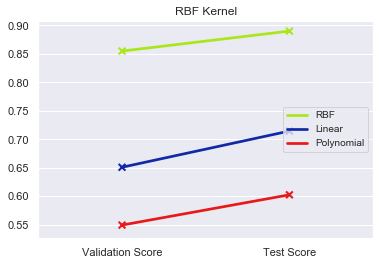

```python
sns.pointplot(x=['Validation Score','Test Score'],y=[svr_val_rbf,svr_test_rbf],markers='x',color="#A9E719"),
sns.pointplot(x=['Validation Score','Test Score'],y=[svr_val_linear,svr_test_linear],markers='x',color="#1128A7"),
sns.pointplot(x=['Validation Score','Test Score'],y=[svr_val_poly,svr_test_poly],markers='x',color="#E71919")
leg = plt.legend(labels=["RBF","Linear","Polynomial"],loc = "center right",prop={'size':'10'})
leg.legendHandles[0].set_color("#A9E719")
leg.legendHandles[1].set_color("#1128A7")
leg.legendHandles[2].set_color("#E71919")
plt.title("RBF Kernel")
plt.show()

# RBF kernel promises the highest accuracy among the three kernels in validation and test set.
# Also, the increase in accuracy (slope of the line) is small, which signifies that the model is not overfit or underfit.

# The model is regularized.
```

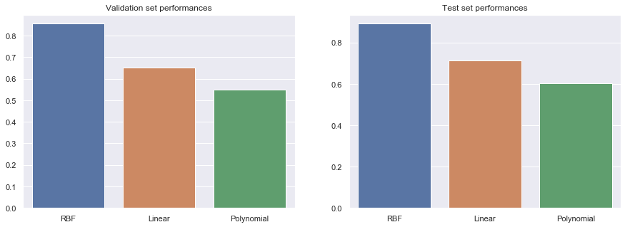

```python
fig,axes = plt.subplots(nrows=1,ncols=2,figsize=(15,5))
ax1 = sns.barplot(x=["RBF","Linear","Polynomial"],y=[svr_val_rbf,svr_val_linear,svr_val_poly],ax=axes[0])
ax2 = sns.barplot(x=["RBF","Linear","Polynomial"],y=[svr_test_rbf,svr_test_linear,svr_test_poly],ax=axes[1])
ax1.title.set_text("Validation set performances")
ax2.title.set_text("Test set performances")
```

We use only RBF Kernel to tune the hyper parameters as it gives the highest performance.

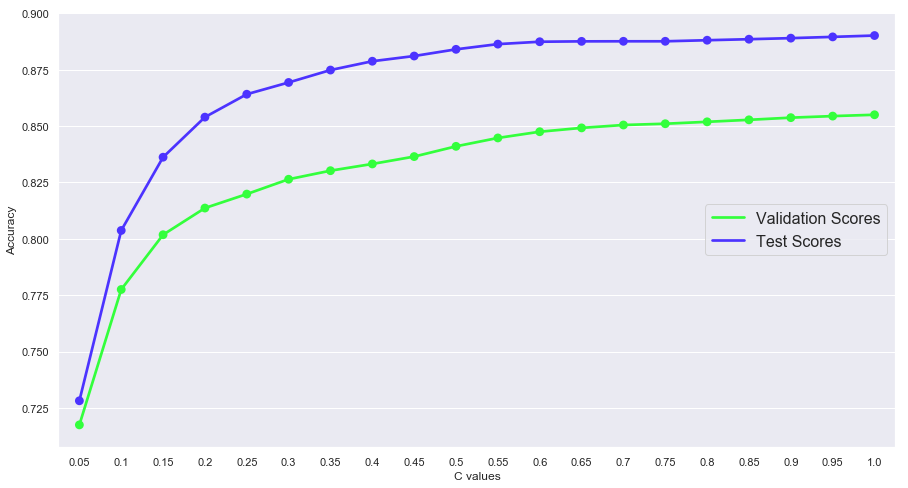

```python
svr_val_scores = []
svr_test_scores = []
c_values = np.arange(0.05,1.05,0.05)

# np.arange() function creates an array of c values which have recurring decimal numbers.
# So to trim them upto 2 decimal places, we use the float positional function to re-format the c values.
for i in range(0,len(c_values)):
    c_values[i] = np.format_float_positional(c_values[i],precision=4)

# Loop to create the regressors with different values of C
for c in c_values:
    svr_tune = svm.SVR(kernel="rbf",C=c)
    svr_tune.fit(X_train_2,y_train_2)
    svr_val_scores.append(svr_tune.score(X_val_2,y_val_2))
    svr_test_scores.append(svr_tune.score(X_test_2,y_test_2))

# Plotting the comparison graph for the regressors with different c values
plt.figure(figsize=(15,8))
sns.pointplot(x = c_values,y=svr_val_scores,color="#33FF3C",label="Validation Scores"),
sns.pointplot(x = c_values,y=svr_test_scores,color="#4C33FF",label="Test Scores")
leg = plt.legend(labels=['Validation Scores','Test Scores'], loc ='center right',prop={'size':16})
leg.legendHandles[0].set_color("#33FF3C")
leg.legendHandles[1].set_color("#4C33FF")
plt.xlabel("C values")
plt.ylabel("Accuracy")
plt.show()

# The model is tuned and regularized well to achieve test scores higher than the validation scores.
# For C=1.00 the model gives one of the highest accuracies.
```